# Exploration of the corpus

Salience of macro-regions & states

Auteur·rice

Etienne Toureille & Claude Grasland

## Introduction

The objective of this short document is to propose some tables and figure of interest for a salience analysis of the states and macro-regions found in the annoted corpus (files stored in the repertory “corpus_geo”). We use a miniumum of packages in order to facilitate the replication.

## A. Settings

### Load annotated corpora

```r
c1<-readRDS("corpus_geo/de_DEU_suddeu_geo.RDS")

c2<-readRDS("corpus_geo/fr_FRA_figaro_geo.RDS")

c3<-readRDS("corpus_geo/en_GBR_indept_geo.RDS")

c4<-readRDS("corpus_geo/fr_TUN_afrman_geo.RDS")

c5<-readRDS("corpus_geo/tr_TUR_dunya_geo.RDS")

df<-rbind(c1,c2,c3,c4,c5)
```

### load dictionary

Import of the dictionary used for data annotation. We will just use it to prepare the table before the visualization in order to write the name of the entities (column *code_name*) rather than the codes (column *code*).

```r
# import the .csv file with the dictionary
dict_df <- read.csv("dict/dict_final.csv",fileEncoding = "UTF-8", sep= ";")
head(dict_df)
```

```
  wikidata lang             alias        code type subtype loc code_name
1      Q15   de            Afrika REG_CON_AFR  REG     CON AFR    Afrika
2      Q15   en            Africa REG_CON_AFR  REG     CON AFR    Africa
3      Q15   en African continent REG_CON_AFR  REG     CON AFR    Africa
4      Q15   en     Ancient Libya REG_CON_AFR  REG     CON AFR    Africa
5      Q15   fr           Afrique REG_CON_AFR  REG     CON AFR   Afrique
6      Q15   tr            Afrika REG_CON_AFR  REG     CON AFR    Afrika
```

### Generalities about the corpus

Identify the number of sources, languages, period of analysis and the total number of articles.

```r
# sources
unique(df$who)
```

```
[1] "DEU_suddeu" "FRA_figaro" "GBR_indept" "TUN_afrman" "TUR_dunya"
```

```r
# languages
unique(df$lang)
```

```
[1] "de" "fr" "en" "tr"
```

```r
# period of analysis
min(df$when)
```

```
[1] "2013-01-01"
```

```r
max(df$when)
```

```
[1] "2023-04-30"
```

```r
# total nomber of articles
nb_titles <- nrow(df)
print(nb_titles)
```

```
[1] 1869721
```

Compute the number of news for each source in a data frame and visualize in a barplot.

```r
# compute total by sources
nb_articles_by_source <- df %>%
  group_by(who) %>%
  summarise(nb_articles_source = n())

# print
kable(nb_articles_by_source)
```

| who | nb_articles_source |
| --- | --- |
| DEU_suddeu | 345040 |
| FRA_figaro | 622861 |
| GBR_indept | 513404 |
| TUN_afrman | 120265 |
| TUR_dunya | 268151 |

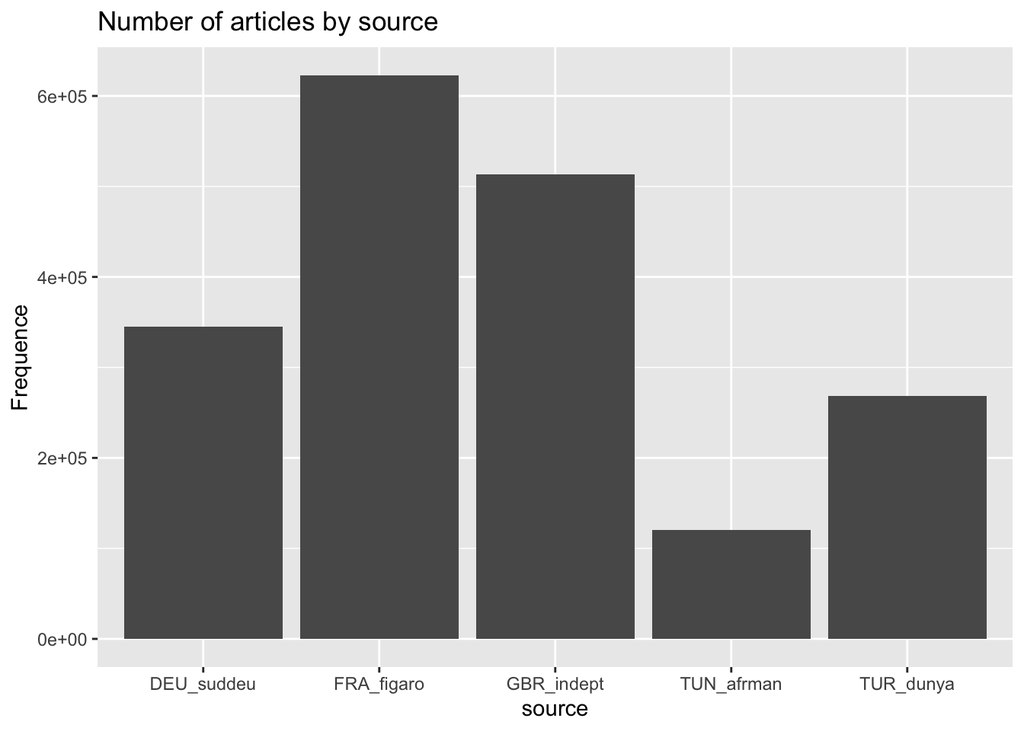

```r
# plot
ggplot(nb_articles_by_source,
       aes(x=who,y=nb_articles_source))+
  geom_bar(stat = "identity")+
  ggtitle("Number of articles by source")+
  xlab("source")+
  ylab("Frequence")
```

## B. Salience of macro-regions

The next step of the analysis consider the individualized salience of each macro-region. The question are: what are the most representd macro-regions in the titles? Which of them are used in each sources?

### Number of titles containing one or more macro-regions

We first compute the frequency of news with at least one macro-région or more in each media of the corpus

```r
df$macro<-cut(df$nbregions, c(-1,0.5,1.5,100))
levels(df$macro)<- c("0", "1","2+")
tab<-table(df$macro,df$who)
tab<-addmargins(tab)
pct<-round(100-100*tab[1,]/tab[4,],1)
tab<-rbind(tab,pct)

colnames(tab)<-c("Südd. Zeitung","Le Figaro","The Independent","Dunya","African Manager", "Full Corpus")
row.names(tab)<-c("0","1", "2+","Total", "Salience (%)")
kable(tab, caption ="Frequency of macroregions by media")
```

Frequency of macroregions by media

|  | Südd. Zeitung | Le Figaro | The Independent | Dunya | African Manager | Full Corpus |
| --- | --- | --- | --- | --- | --- | --- |
| 0 | 335893.0 | 607436.0 | 498466.0 | 117341.0 | 258160.0 | 1817296.0 |
| 1 | 8972.0 | 15209.0 | 14724.0 | 2833.0 | 9647.0 | 51385.0 |
| 2+ | 175.0 | 216.0 | 214.0 | 91.0 | 344.0 | 1040.0 |
| Total | 345040.0 | 622861.0 | 513404.0 | 120265.0 | 268151.0 | 1869721.0 |
| Salience (%) | 2.7 | 2.5 | 2.9 | 2.4 | 3.7 | 2.8 |

```r
write.table(tab,"explor_results/tab_salience_macroregion.csv", row.names=T)
```

### Unnest regions

We filter the news where the number of region is greater or equal to 0 and we duplicate the news where more that one region is mentionend with the function *unnest()* :

```r
# unnest regions
df2<-  df %>% filter(nbregions >0) %>%
          mutate(reg = str_split(regions, " ")) %>%
          unnest(reg) %>%
          select(who,reg)
```

### Aggregation and ranking

Now we can aggregate the number of regions and compute the rank, frequency and cumulative frequency. We add the name in english.

```r
## full corpus
tabtot <- df2 %>% mutate(who="All") %>%
                  group_by(who,reg) %>%
                  count() %>%
                  group_by(who) %>%
                  arrange(-n) %>%
                  mutate(rnk=rank(-n),
                         pct=100*n/sum(n),
                         cum = cumsum(pct)
                         )
## By media
tabmed <- df2 %>% group_by(who,reg) %>%
                  count() %>%
                  group_by(who) %>%
                  arrange(-n) %>%
                  mutate(rnk=rank(-n),
                         pct=100*n/sum(n),
                         cum = cumsum(pct)
                         )
# Join
tabres <-rbind(tabmed, tabtot)


## add name
name_en<-dict_df %>% filter(lang=="en") %>% mutate(reg=substr(code,5,100)) %>% select(reg, name=code_name) %>% unique()
tabres<-tabres %>% left_join(name_en) %>% select(who,reg,name,rnk, n,pct,cum) %>% arrange(who)
```

### Table of top 10 by country

We extract the 10 most mentionned macro-regions by media and for the whole corpus

```r
top10<- tabres %>% filter(rnk < 11) %>%
           select(who, rnk, name) %>%
           pivot_wider(values_from = name,names_from = c(who))
kable(top10, caption = "Top 10 macro-regions by media")
```

Top 10 macro-regions by media

| rnk | All | DEU_suddeu | FRA_figaro | GBR_indept | TUN_afrman | TUR_dunya |
| --- | --- | --- | --- | --- | --- | --- |
| 1 | E.U. | E.U. | E.U. | E.U. | E.U. | E.U. |
| 2 | Europe | Europe | Europe | Europe | Africa | Europe |
| 3 | Africa | NATO | NATO | Europa League (UEFA) | Europe | Mediterranean |
| 4 | NATO | Europa League (UEFA) | Africa | Mid East | EBRD | Asia |
| 5 | Mediterranean | Africa | Mediterranean | NATO | Mediterranean | Africa |
| 6 | Europa League (UEFA) | Mediterranean | Alpeia | Africa | Arab countries | NATO |
| 7 | Asia | Mid East | Asia | Arctic | Maghrib | Black Sea |
| 8 | Mid East | Alpeia | Sahel | Mediterranean | Sahel | Europa League (UEFA) |
| 9 | Alpeia | Asia | Amazon | Occident | NATO | EBRD |
| 10 | Arctic | Balkans | Europa League (UEFA) | Commonwealth | Francophonie | Mid East |

```r
write.table(top10,"explor_results/tab_top10_macroregions.csv", sep=";",row.names = F)
```

### Rank size rule

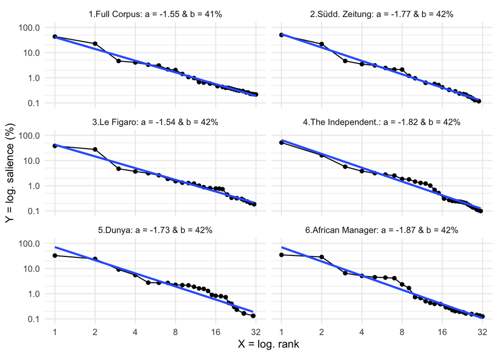

```r
### Extract top20
top20<- tabres %>% filter(rnk < 33 ) %>%
           select(who, rnk, pct, name)

### Compute model parameters
mod_ranksize<-lm(formula = log(top20$pct)~top20$who+log(top20$rnk):top20$who)
param<-mod_ranksize$coefficients
b<-exp(param[1:6])
b[2:6]<-b[2:6]+b[1]
a<-param[7:12]
media<-c("1.Full Corpus","2.Südd. Zeitung","3.Le Figaro","4.The Independent.","5.Dunya","6.African Manager")
leg<-paste0(media,": a = ",round(a,2) ," & b = ",round(b,0),"%")
who<-unique(top20$who)
tabmod<-data.frame(leg,who)

# Add parameters to dataframe
top20 <- top20 %>% left_join(tabmod)


fig <- ggplot(top20) + aes(x=rnk, y=pct) +
          geom_line() +
          geom_point() +
          geom_smooth(fill = NA, method="lm") +
          scale_x_log10("X = log. rank", breaks= c(1,2,4,8,16,32), minor_breaks=NULL)+
          scale_y_log10("Y = log. salience (%)", breaks=c(0.1,1,10,100),
                        minor_breaks=c(0.2, 0.5,2,5,20,50)) +
          facet_wrap(~leg,nrow = 3) +
          theme_minimal()

fig
```

```r
ggsave(plot=fig,filename = "explor_results/fig_rnksize_macroregions.pdf",width=6, height=7)
```

## C. Salience of states

We apply the same procedure to the case of foreign states i.e. states mentioned, excluding the home country of themedia

```r
df$home<-as.numeric(df$states==substr(df$who,1,3))
df$stato<-df$nbstates-df$home
df$stato<-cut(df$stato, c(-1,0.5,1.5,100))
levels(df$stato)<- c("0", "1","2+")
tab<-table(df$stato,df$who)
tab<-addmargins(tab)
pct<-round(100-100*tab[1,]/tab[4,],1)
tab<-rbind(tab,pct)


colnames(tab)<-c("Südd. Zeitung","Le Figaro","The Independent","Dunya","African Manager", "Full Corpus")
row.names(tab)<-c("0","1", "2+","Total", "Salience (%)")
kable(tab, caption ="Frequency of foreign states by media")
```

Frequency of foreign states by media

|  | Südd. Zeitung | Le Figaro | The Independent | Dunya | African Manager | Full Corpus |
| --- | --- | --- | --- | --- | --- | --- |
| 0 | 296711 | 482772.0 | 406852.0 | 102772.0 | 227463.0 | 1516570.0 |
| 1 | 43358 | 120729.0 | 87755.0 | 11552.0 | 32806.0 | 296200.0 |
| 2+ | 4971 | 19360.0 | 18797.0 | 5941.0 | 7882.0 | 56951.0 |
| Total | 345040 | 622861.0 | 513404.0 | 120265.0 | 268151.0 | 1869721.0 |
| Salience (%) | 14 | 22.5 | 20.8 | 14.5 | 15.2 | 18.9 |

```r
write.table(tab,"explor_results/tab_salience_states.csv", row.names=T)
```

### Unnest foreign states

We filter the news where the number of states is greater or equal to 0 and we duplicate the news where more that one region is mentionend with the function *unnest()*. Then we eliminate the home countries

```r
# unnest states and keep foreign
df3<-  df %>% filter(nbstates>0) %>%
          mutate(sta = str_split(states, " ")) %>%
          unnest(sta) %>%
          select(who,sta) %>%
          filter(substr(who,1,3)!=sta)
```

### Aggregation and ranking

Now we can aggregate the number of states and compute the rank, frequency and cumulative frequency. We add the name in english.

```r
## full corpus
tabtot <- df3 %>% mutate(who="All") %>%
                  group_by(who,sta) %>%
                  count() %>%
                  group_by(who) %>%
                  arrange(-n) %>%
                  mutate(rnk=rank(-n),
                         pct=100*n/sum(n),
                         cum = cumsum(pct)
                         )
## By media
tabmed <- df3 %>% group_by(who,sta) %>%
                  count() %>%
                  group_by(who) %>%
                  arrange(-n) %>%
                  mutate(rnk=rank(-n),
                         pct=100*n/sum(n),
                         cum = cumsum(pct)
                         )
# Join
tabres <-rbind(tabmed, tabtot)


## add name
 name_en<-dict_df %>% filter(lang=="en",
                             substr(code,1,7)=="STA_NAM")  %>%
   mutate(sta=substr(code,9,100)) %>%
   select(sta, name=code_name) %>%
   unique()

tabres<-tabres %>% left_join(name_en) %>% select(who,sta,name,rnk, n,pct,cum) %>% arrange(who)
```

### Table of top 10 by country

```r
top10<- tabres %>% filter(rnk < 11) %>%
           select(who, rnk, name) %>%
           pivot_wider(values_from = name,names_from = c(who))
kable(top10, caption = "Top 10 states mentions in each media")
```

Top 10 states mentions in each media

| rnk | All | DEU_suddeu | FRA_figaro | GBR_indept | TUN_afrman | TUR_dunya |
| --- | --- | --- | --- | --- | --- | --- |
| 1 | USA | USA | USA | USA | USA | USA |
| 2 | Russia | Russia | Russia | Russia | France | Russia |
| 3 | China | France | United Kingdom | France | Libya | China |
| 4 | Syria | Ukraine | China | China | Algeria | United Kingdom |
| 5 | United Kingdom | United Kingdom | Syria | Syria | Morocco | Germany |
| 6 | Ukraine | China | Germany | Germany | Syria | Iran |
| 7 | France | Turkey | Ukraine | Australia | Italia | Syria |
| 8 | Germany | Italia | Turkey | India | Turkey | Ukraine |
| 9 | Turkey | Syria | Italia | Israel | Germany | France |
| 10 | Italia | Greece | Israel | Italia | Russia | Iraq |

```r
write.table(top10,"explor_results/tab_top10_states.csv", sep=";",row.names = F)
```

### Rank size rule

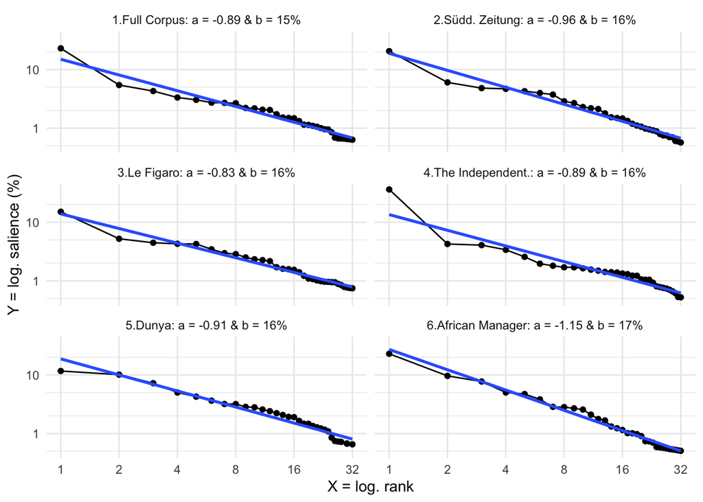

```r
### Extract top20
top20<- tabres %>% filter(rnk < 33 ) %>%
           select(who, rnk, pct, name)

### Compute model parameters
mod_ranksize<-lm(formula = log(top20$pct)~top20$who+log(top20$rnk):top20$who)
param<-mod_ranksize$coefficients
b<-exp(param[1:6])
b[2:6]<-b[2:6]+b[1]
a<-param[7:12]
media<-c("1.Full Corpus","2.Südd. Zeitung","3.Le Figaro","4.The Independent.","5.Dunya","6.African Manager")
leg<-paste0(media,": a = ",round(a,2) ," & b = ",round(b,0),"%")
who<-unique(top20$who)
tabmod<-data.frame(leg,who)

# Add parameters to dataframe
top20 <- top20 %>% left_join(tabmod)


fig <- ggplot(top20) + aes(x=rnk, y=pct) +
          geom_line() +
          geom_point() +
          geom_smooth(fill = NA, method="lm") +
          scale_x_log10("X = log. rank", breaks= c(1,2,4,8,16,32), minor_breaks=NULL)+
          scale_y_log10("Y = log. salience (%)", breaks=c(0.1,1,10),
                        minor_breaks=c(0.2, 0.5,2,5,20)) +
          facet_wrap(~leg,nrow = 3) +
          theme_minimal()

fig
```

```r
ggsave(plot=fig,filename = "explor_results/fig_rnksize_states.pdf",width=6, height=7)
```

## D. Linkages between states & macro-regions

Compute a matrix of contingency table crossing the detection of states and region in the corpus.

```r
df2<-df
# contingency table region vs. states
df2$nbregions <- ifelse(df2$nbregions>0,"1+ regions ","No regions")
df2$nbstates <- ifelse(df2$nbstates >0,"1+ states","No states")
tab<-table(df2$nbstates,df2$nbregions)
tab<-addmargins(100*prop.table(tab))
kable(tab, caption = "Cross distribution of states and macro-regions in full corpus", digits=2)
```

Cross distribution of states and macro-regions in full corpus

|  | 1+ regions | No regions | Sum |
| --- | --- | --- | --- |
| 1+ states | 1.09 | 25.86 | 26.95 |
| No states | 1.72 | 71.33 | 73.05 |
| Sum | 2.80 | 97.20 | 100.00 |

```r
write.table(tab,"explor_results/cross_table_macroregions_states.csv")
```

### unnest states & regions

```r
# unnest states and regions
df4<-  df %>% filter(nbstates>0, nbregions >0) %>%
          mutate(sta = str_split(states, " ")) %>%
          unnest(sta) %>%
          select(who,sta, regions) %>%
          mutate(reg = str_split(regions, " ")) %>%
          unnest(reg) %>%
          select(who,sta, reg) %>%
          filter(sta != substr(who,1,3)) %>%
          group_by(sta,reg) %>%
          count() %>%
         ungroup()


# add regional and country names
name_reg<-dict_df %>% filter(lang=="en") %>% mutate(reg=substr(code,5,100)) %>% select(reg, regname=code_name) %>% unique()
 name_sta<-dict_df %>% filter(lang=="en", substr(code,1,7)=="STA_NAM")  %>%
   mutate(sta=substr(code,9,100)) %>%
   select(sta, staname=code_name) %>%
   unique()
df4<-df4 %>% left_join(name_reg) %>%
             left_join(name_sta) %>%
             mutate(rnk = rank(-n),
                    pct = 100*n/sum(n)) %>%
             select(rnk,staname,regname,n,pct) %>%
             arrange(rnk)

kable(head(df4,20), caption = "Top 20 of most frequent associations of states and macro-regions",
      digits= c(0,0,0,0,2))
```

Top 20 of most frequent associations of states and macro-regions

| rnk | staname | regname | n | pct |
| --- | --- | --- | --- | --- |
| 1 | USA | E.U. | 818 | 5.20 |
| 2 | Russia | E.U. | 585 | 3.72 |
| 3 | USA | Europe | 569 | 3.62 |
| 4 | United Kingdom | E.U. | 560 | 3.56 |
| 5 | Turkey | E.U. | 497 | 3.16 |
| 6 | Ukraine | E.U. | 454 | 2.89 |
| 7 | Russia | NATO | 377 | 2.40 |
| 8 | Greece | E.U. | 374 | 2.38 |
| 9 | USA | NATO | 319 | 2.03 |
| 10 | Russia | Europe | 277 | 1.76 |
| 11 | Germany | E.U. | 262 | 1.67 |
| 12 | USA | Mid East | 239 | 1.52 |
| 13 | China | E.U. | 216 | 1.37 |
| 14 | Poland | E.U. | 214 | 1.36 |
| 15 | Italia | E.U. | 211 | 1.34 |
| 16 | Ukraine | NATO | 209 | 1.33 |
| 17 | Germany | Europe | 196 | 1.25 |
| 18 | France | E.U. | 170 | 1.08 |
| 19 | Hungary | E.U. | 162 | 1.03 |
| 20 | United Kingdom | Europe | 159 | 1.01 |

```r
write.table(head(df4,20),file = "explor_results/tab_top20_links.csv",row.names = F)
```